# Question

En una academia de patinaje hay 213 estudiantes, repartidos por niveles, de la siguiente forma:

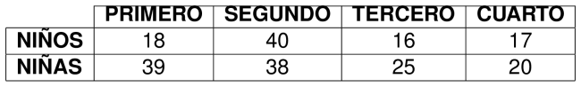

Se tienen, además, las siguientes expresiones:

I. La probabilidad de que sea un niño de tercero es de 37/213  
II. La probabilidad de que sea una niña es de 122/213  
III. La probabilidad de que sea un niño es de 91/213  
IV. La probabilidad de que sea un niño de cuarto es de 17/213

Si se elige un estudiante al azar, ¿cuál de las afirmaciones anteriores es INCORRECTA?

## Answerlist

- La expresión I, porque el número de estudiantes es 213 y la cantidad de niños de tercero es 16; por tanto, la probabilidad es 16/213
- La expresión II, porque el número de estudiantes es 213 y la cantidad de niñas es 122; por tanto, la probabilidad es 122/213
- La expresión III, esa no es la probabilidad, porque el número de casos de niños es 91, pero, el número de casos totales sigue siendo 213
- La expresión IV, porque el número de estudiantes es 213 y la cantidad de niños de cuarto es 17; por tanto, la probabilidad es 17/213

# Solution

La afirmación INCORRECTA es: “I. La probabilidad de que sea un niño de tercero es de 37/213”

# Meta-information

exname: CND10S223-46_v02_opA_tiA(single-choice) extype: schoice exsolution: 1000 exshuffle: FALSE